# Math3021 DB92728-3 VAN HOU HEI

```r
#install("ISLR2")
library (ISLR2)
library(Hmisc) # for corrlation matrix
library(ggplot2) #of cuz we need to plot the graph
Boston
```

|  | crim | zn | indus | chas | nox | rm | age | dis | rad | tax | ptratio | lstat | medv |
| --- | --- | --- | --- | --- | --- | --- | --- | --- | --- | --- | --- | --- | --- |
| 1 | 0.00632 | 18.0 | 2.31 | 0 | 0.5380 | 6.575 | 65.2 | 4.0900 | 1 | 296 | 15.3 | 4.98 | 24.0 |
| 2 | 0.02731 | 0.0 | 7.07 | 0 | 0.4690 | 6.421 | 78.9 | 4.9671 | 2 | 242 | 17.8 | 9.14 | 21.6 |
| 3 | 0.02729 | 0.0 | 7.07 | 0 | 0.4690 | 7.185 | 61.1 | 4.9671 | 2 | 242 | 17.8 | 4.03 | 34.7 |
| 4 | 0.03237 | 0.0 | 2.18 | 0 | 0.4580 | 6.998 | 45.8 | 6.0622 | 3 | 222 | 18.7 | 2.94 | 33.4 |
| 5 | 0.06905 | 0.0 | 2.18 | 0 | 0.4580 | 7.147 | 54.2 | 6.0622 | 3 | 222 | 18.7 | 5.33 | 36.2 |
| 6 | 0.02985 | 0.0 | 2.18 | 0 | 0.4580 | 6.430 | 58.7 | 6.0622 | 3 | 222 | 18.7 | 5.21 | 28.7 |
| 7 | 0.08829 | 12.5 | 7.87 | 0 | 0.5240 | 6.012 | 66.6 | 5.5605 | 5 | 311 | 15.2 | 12.43 | 22.9 |
| 8 | 0.14455 | 12.5 | 7.87 | 0 | 0.5240 | 6.172 | 96.1 | 5.9505 | 5 | 311 | 15.2 | 19.15 | 27.1 |
| 9 | 0.21124 | 12.5 | 7.87 | 0 | 0.5240 | 5.631 | 100.0 | 6.0821 | 5 | 311 | 15.2 | 29.93 | 16.5 |
| 10 | 0.17004 | 12.5 | 7.87 | 0 | 0.5240 | 6.004 | 85.9 | 6.5921 | 5 | 311 | 15.2 | 17.10 | 18.9 |

[output cut: 496 more lines]

```r
?Boston
```

How many rows are in this data set? How many columns? What do the rows and columns represent?

```r
dim(Boston) #506 column , 13 rows
```

```
[1] 506  13
```

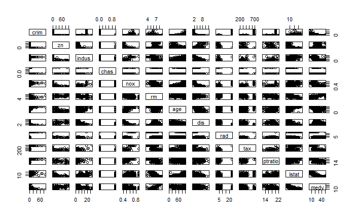

```r
Boston$chas <- as.numeric(Boston$chas) # we need to convert int to double
Boston$rad <- as.numeric(Boston$rad)# we need to convert int to double
pairs(Boston) # pairwise scatterplots
```

some of them varabiles are correlated. by part (b) we look for correlation matrix

```r
flattenCorrMatrix <- function(cormat, pmat) {
  ut <- upper.tri(cormat)
  data.frame(
    row = rownames(cormat)[row(cormat)[ut]],
    column = rownames(cormat)[col(cormat)[ut]],
    cor  =(cormat)[ut],
    p = pmat[ut]
    )
}
res2<-rcorr(as.matrix(Boston))
flattenCorrMatrix(res2$r, res2$P)
```

| row | column | cor | p |
| --- | --- | --- | --- |
| crim | zn | -0.200469220 | 5.506472e-06 |
| crim | indus | 0.406583411 | 0.000000e+00 |
| zn | indus | -0.533828186 | 0.000000e+00 |
| crim | chas | -0.055891582 | 2.094345e-01 |
| zn | chas | -0.042696719 | 3.378103e-01 |
| indus | chas | 0.062938027 | 1.574628e-01 |
| crim | nox | 0.420971711 | 0.000000e+00 |
| zn | nox | -0.516603708 | 0.000000e+00 |
| indus | nox | 0.763651447 | 0.000000e+00 |
| chas | nox | 0.091202807 | 4.029050e-02 |

[output cut: 68 more lines]

by the result(corrlation coefficient and p-values) abrove we can denote there are corrlation between crime rate with other columns(predictor)

```r
lapply(Boston, summary)
```

```
$crim
    Min.  1st Qu.   Median     Mean  3rd Qu.     Max.
 0.00632  0.08204  0.25651  3.61352  3.67708 88.97620

$zn
   Min. 1st Qu.  Median    Mean 3rd Qu.    Max.
   0.00    0.00    0.00   11.36   12.50  100.00

$indus
   Min. 1st Qu.  Median    Mean 3rd Qu.    Max.
   0.46    5.19    9.69   11.14   18.10   27.74

$chas
   Min. 1st Qu.  Median    Mean 3rd Qu.    Max.
0.00000 0.00000 0.00000 0.06917 0.00000 1.00000

$nox
   Min. 1st Qu.  Median    Mean 3rd Qu.    Max.
 0.3850  0.4490  0.5380  0.5547  0.6240  0.8710

$rm
   Min. 1st Qu.  Median    Mean 3rd Qu.    Max.
  3.561   5.886   6.208   6.285   6.623   8.780

$age
   Min. 1st Qu.  Median    Mean 3rd Qu.    Max.
   2.90   45.02   77.50   68.57   94.08  100.00

$dis
   Min. 1st Qu.  Median    Mean 3rd Qu.    Max.
  1.130   2.100   3.207   3.795   5.188  12.127

$rad
   Min. 1st Qu.  Median    Mean 3rd Qu.    Max.
  1.000   4.000   5.000   9.549  24.000  24.000

$tax
   Min. 1st Qu.  Median    Mean 3rd Qu.    Max.
  187.0   279.0   330.0   408.2   666.0   711.0

$ptratio
   Min. 1st Qu.  Median    Mean 3rd Qu.    Max.
  12.60   17.40   19.05   18.46   20.20   22.00

$lstat
   Min. 1st Qu.  Median    Mean 3rd Qu.    Max.
   1.73    6.95   11.36   12.65   16.95   37.97

$medv
   Min. 1st Qu.  Median    Mean 3rd Qu.    Max.
   5.00   17.02   21.20   22.53   25.00   50.00
```

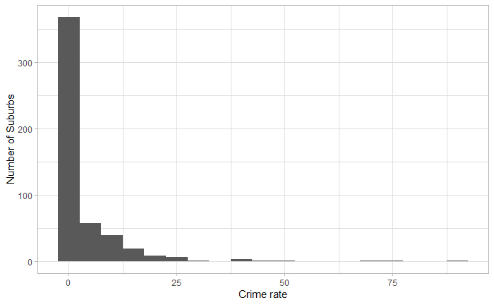

```r
qplot(Boston$crim, binwidth=5, xlab= "Crime rate", ylab= "Number of Suburbs")+ theme_light()
```

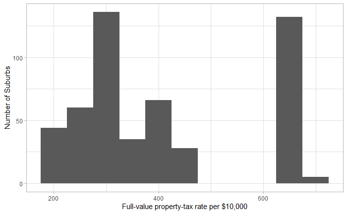

```r
qplot(Boston$tax, binwidth=50, xlab="Full-value property-tax rate per $10,000", ylab="Number of Suburbs")+ theme_light()
```

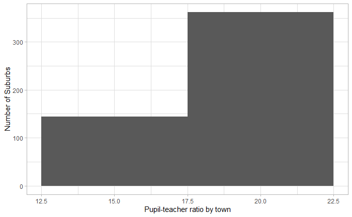

```r
qplot(Boston$ptratio, binwidth=5, xlab="Pupil-teacher ratio by town", ylab="Number of Suburbs")   + theme_light()
```

```r
NA
NA
```

First graph we denoted that the median and maximum crime rate values are 0.25651 and 88.97620 repectively

```r
for(i in 1:5)
{
   perIndex = i * 10
   selection <- subset(Boston, crim>perIndex )
   rate <- nrow(selection) / nrow(Boston) * 100
   result <- paste(rate, "% neighborhood have crime rate abrove " ,perIndex  , "%", sep=" ")
   print(result)
}
```

```
[1] "10.6719367588933 % neighborhood have crime rate abrove  10 %"
[1] "3.55731225296443 % neighborhood have crime rate abrove  20 %"
[1] "1.58102766798419 % neighborhood have crime rate abrove  30 %"
[1] "1.18577075098814 % neighborhood have crime rate abrove  40 %"
[1] "0.790513833992095 % neighborhood have crime rate abrove  50 %"
```

since by the tax rate graph we missed the region 4xx ~ 600+ so

```r
selection <- subset(Boston, tax<600)
nrow(selection) / nrow(Boston) * 100
```

```
[1] 72.9249
```

```r
selection <- subset(Boston, tax>600)
nrow(selection) / nrow(Boston) * 100
```

```
[1] 27.0751
```

How many of the census tracts in this data set bound the Charles river?

```r
ans <-nrow(subset(Boston, chas==1)) # chas is charles river where i is contained
print(paste("num of charles river" , ans))
```

```
[1] "num of charles river 35"
```

What is the median pupil-teacher ratio among the towns in this data set?

```r
ans <- median(Boston$ptratio)
print(paste("the median is " , ans))
```

```
[1] "the median is  19.05"
```

Which census tract of Boston has lowest median value of owneroccupied homes? What are the values of the other predictors for that census tract, and how do those values compare to the overall ranges for those predictors? Comment on your findings.

```r
ans <- Boston[order(Boston$medv),] #order by aes first element must be  lowest
summary(ans)
```

```
      crim                zn             indus            chas              nox               rm
 Min.   : 0.00632   Min.   :  0.00   Min.   : 0.46   Min.   :0.00000   Min.   :0.3850   Min.   :3.561
 1st Qu.: 0.08205   1st Qu.:  0.00   1st Qu.: 5.19   1st Qu.:0.00000   1st Qu.:0.4490   1st Qu.:5.886
 Median : 0.25651   Median :  0.00   Median : 9.69   Median :0.00000   Median :0.5380   Median :6.208
 Mean   : 3.61352   Mean   : 11.36   Mean   :11.14   Mean   :0.06917   Mean   :0.5547   Mean   :6.285
 3rd Qu.: 3.67708   3rd Qu.: 12.50   3rd Qu.:18.10   3rd Qu.:0.00000   3rd Qu.:0.6240   3rd Qu.:6.623
 Max.   :88.97620   Max.   :100.00   Max.   :27.74   Max.   :1.00000   Max.   :0.8710   Max.   :8.780
      age              dis              rad              tax           ptratio          lstat
 Min.   :  2.90   Min.   : 1.130   Min.   : 1.000   Min.   :187.0   Min.   :12.60   Min.   : 1.73
 1st Qu.: 45.02   1st Qu.: 2.100   1st Qu.: 4.000   1st Qu.:279.0   1st Qu.:17.40   1st Qu.: 6.95
 Median : 77.50   Median : 3.207   Median : 5.000   Median :330.0   Median :19.05   Median :11.36
 Mean   : 68.57   Mean   : 3.795   Mean   : 9.549   Mean   :408.2   Mean   :18.46   Mean   :12.65
 3rd Qu.: 94.08   3rd Qu.: 5.188   3rd Qu.:24.000   3rd Qu.:666.0   3rd Qu.:20.20   3rd Qu.:16.95
 Max.   :100.00   Max.   :12.127   Max.   :24.000   Max.   :711.0   Max.   :22.00   Max.   :37.97
      medv
 Min.   : 5.00
 1st Qu.:17.02
 Median :21.20
 Mean   :22.53
 3rd Qu.:25.00
 Max.   :50.00
```

```r
ans[1,]
```

|  | crim | zn | indus | chas | nox | rm | age | dis | rad | tax | ptratio | lstat | medv |
| --- | --- | --- | --- | --- | --- | --- | --- | --- | --- | --- | --- | --- | --- |
| 399 | 38.3518 | 0 | 18.1 | 0 | 0.693 | 5.453 | 100 | 1.4896 | 24 | 666 | 20.2 | 30.59 | 5 |

There is no residential land zoned for lots exceeding 25,000 sq.ft., which is quite high when compared to the median and average crime rates of all Boston areas. This is true in more than half of Boston’s neighborhoods.  
In comparison to most suburbs, the proportion of non-retail business acres per town is relatively high.

This is not one of the suburbs that surrounds the Charles River.  
The content of nitrogen oxides (parts per 10 million) is one of the highest.

The average number of rooms per household is one of the lowest in the country.

Owner-occupied units built before to 1940 have the highest proportion of owners.

One of the shortest weighted average distances to five Boston job centers.

The highest accessibility index for radial roads.

One of the highest full-value property-tax rates per $10,000 in the United States.  
One of the town’s highest pupil-to-teacher ratios.

One of the population’s lowest socioeconomic status (percent).

In the $1000s, the lowest median value of owner-occupied dwellings.

In this data set, how many of the census tracts average more than seven rooms per dwelling? More than eight rooms per dwelling? Comment on the census tracts that average more than eight rooms per dwelling.

```r
for(i in 6:8)
{
   ans <- (subset(Boston, rm>i))
   noOf<- nrow(ans)
   print(paste("There are ",noOf, " suburbs with more than " , i ," rooms per dwelling." ))
   print(summary(ans))


}
```

```
[1] "There are  333  suburbs with more than  6  rooms per dwelling."
      crim                zn             indus             chas              nox               rm
 Min.   : 0.00632   Min.   :  0.00   Min.   : 0.460   Min.   :0.00000   Min.   :0.3850   Min.   :6.003
 1st Qu.: 0.06076   1st Qu.:  0.00   1st Qu.: 3.970   1st Qu.:0.00000   1st Qu.:0.4420   1st Qu.:6.211
 Median : 0.17004   Median :  0.00   Median : 7.380   Median :0.00000   Median :0.5070   Median :6.454
 Mean   : 2.53490   Mean   : 14.94   Mean   : 9.781   Mean   :0.07207   Mean   :0.5363   Mean   :6.628
 3rd Qu.: 1.83377   3rd Qu.: 22.00   3rd Qu.:18.100   3rd Qu.:0.00000   3rd Qu.:0.6140   3rd Qu.:6.854
 Max.   :88.97620   Max.   :100.00   Max.   :25.650   Max.   :1.00000   Max.   :0.8710   Max.   :8.780
      age             dis              rad              tax           ptratio          lstat
 Min.   :  2.9   Min.   : 1.169   Min.   : 1.000   Min.   :187.0   Min.   :12.60   Min.   : 1.73
 1st Qu.: 38.5   1st Qu.: 2.296   1st Qu.: 4.000   1st Qu.:273.0   1st Qu.:16.60   1st Qu.: 5.70
 Median : 71.6   Median : 3.495   Median : 5.000   Median :307.0   Median :18.40   Median : 8.67
 Mean   : 64.6   Mean   : 4.068   Mean   : 8.982   Mean   :389.6   Mean   :18.13   Mean   :10.18
 3rd Qu.: 91.1   3rd Qu.: 5.492   3rd Qu.: 8.000   3rd Qu.:437.0   3rd Qu.:20.20   3rd Qu.:13.44
 Max.   :100.0   Max.   :12.127   Max.   :24.000   Max.   :666.0   Max.   :21.20   Max.   :29.05
      medv
 Min.   : 7.20
 1st Qu.:19.40
 Median :23.30
 Mean   :25.16
 3rd Qu.:29.80
 Max.   :50.00
[1] "There are  64  suburbs with more than  7  rooms per dwelling."
      crim                zn            indus             chas            nox               rm
 Min.   : 0.00906   Min.   : 0.00   Min.   : 0.460   Min.   :0.000   Min.   :0.3940   Min.   :7.007
 1st Qu.: 0.04502   1st Qu.: 0.00   1st Qu.: 2.460   1st Qu.:0.000   1st Qu.:0.4303   1st Qu.:7.183
 Median : 0.09786   Median :20.00   Median : 3.970   Median :0.000   Median :0.4880   Median :7.414
 Mean   : 0.97911   Mean   :28.17   Mean   : 5.776   Mean   :0.125   Mean   :0.5045   Mean   :7.570
 3rd Qu.: 0.54289   3rd Qu.:45.00   3rd Qu.: 6.200   3rd Qu.:0.000   3rd Qu.:0.5825   3rd Qu.:7.859
 Max.   :19.60910   Max.   :95.00   Max.   :19.580   Max.   :1.000   Max.   :0.7180   Max.   :8.780
      age              dis             rad              tax           ptratio          lstat
 Min.   :  8.40   Min.   :1.202   Min.   : 1.000   Min.   :193.0   Min.   :12.60   Min.   : 1.730
 1st Qu.: 36.00   1st Qu.:2.445   1st Qu.: 3.000   1st Qu.:244.8   1st Qu.:14.70   1st Qu.: 3.555
 Median : 63.80   Median :3.495   Median : 5.000   Median :273.0   Median :17.40   Median : 4.775
 Mean   : 60.64   Mean   :4.200   Mean   : 5.984   Mean   :312.2   Mean   :16.26   Mean   : 5.474
 3rd Qu.: 85.03   3rd Qu.:5.463   3rd Qu.: 7.000   3rd Qu.:329.0   3rd Qu.:17.93   3rd Qu.: 6.590
 Max.   :100.00   Max.   :9.223   Max.   :24.000   Max.   :666.0   Max.   :20.20   Max.   :16.740
      medv
 Min.   :15.00
 1st Qu.:32.98
 Median :36.45
 Mean   :38.40
 3rd Qu.:46.17
 Max.   :50.00
[1] "There are  13  suburbs with more than  8  rooms per dwelling."
      crim               zn            indus             chas             nox               rm
 Min.   :0.02009   Min.   : 0.00   Min.   : 2.680   Min.   :0.0000   Min.   :0.4161   Min.   :8.034
 1st Qu.:0.33147   1st Qu.: 0.00   1st Qu.: 3.970   1st Qu.:0.0000   1st Qu.:0.5040   1st Qu.:8.247
 Median :0.52014   Median : 0.00   Median : 6.200   Median :0.0000   Median :0.5070   Median :8.297
 Mean   :0.71879   Mean   :13.62   Mean   : 7.078   Mean   :0.1538   Mean   :0.5392   Mean   :8.349
 3rd Qu.:0.57834   3rd Qu.:20.00   3rd Qu.: 6.200   3rd Qu.:0.0000   3rd Qu.:0.6050   3rd Qu.:8.398
 Max.   :3.47428   Max.   :95.00   Max.   :19.580   Max.   :1.0000   Max.   :0.7180   Max.   :8.780
      age             dis             rad              tax           ptratio          lstat           medv
 Min.   : 8.40   Min.   :1.801   Min.   : 2.000   Min.   :224.0   Min.   :13.00   Min.   :2.47   Min.   :21.9
 1st Qu.:70.40   1st Qu.:2.288   1st Qu.: 5.000   1st Qu.:264.0   1st Qu.:14.70   1st Qu.:3.32   1st Qu.:41.7
 Median :78.30   Median :2.894   Median : 7.000   Median :307.0   Median :17.40   Median :4.14   Median :48.3
 Mean   :71.54   Mean   :3.430   Mean   : 7.462   Mean   :325.1   Mean   :16.36   Mean   :4.31   Mean   :44.2
 3rd Qu.:86.50   3rd Qu.:3.652   3rd Qu.: 8.000   3rd Qu.:307.0   3rd Qu.:17.40   3rd Qu.:5.12   3rd Qu.:50.0
 Max.   :93.90   Max.   :8.907   Max.   :24.000   Max.   :666.0   Max.   :20.20   Max.   :7.44   Max.   :50.0
```